# Data Analysis

Sridhar

28 January 2019

```r
#install.packages("ggplot2")
#install.packages("ggvis")
#install.packages("mice")
library(ggplot2)
library(ggvis)
library(knitr)
library(mice)
library(caret)
library(doParallel)
```

## Load the Data

Breast Cancer Wisconsin(Diagnosis) data is loaded and the column names are defined based on the attribute information.

### Dataset 1

The outcome variable is the “classes” and it has following category of data

- Malignant or
- Benign breast mass

The phenotypes for characterization are * Sample ID (code number) * Clump thickness * Uniformity of cell size * Uniformity of cell shape * Marginal adhesion * Single epithelial cell size * Number of bare nuclei * Bland chromatin * Number of normal nuclei * Mitosis * Classes, i.e. diagnosis

```r
diagnosis_data <- read.csv("~/Desktop/BreastCancer/Data/breast-cancer-wisconsin.data.csv", header = FALSE)
colnames(diagnosis_data) <- c("sample_code_number", "clump_thickness", "uniformity_of_cell_size", "uniformity_of_cell_shape", "marginal_adhesion", "single_epithelial_cell_size",
                       "bare_nuclei", "bland_chromatin", "normal_nucleoli", "mitosis", "classes")
```

```r
# impute missing data

diagnosis_data[,2:10] <- apply(diagnosis_data[, 2:10], 2, function(x) as.numeric(as.character(x)))
dataset_impute <- mice(diagnosis_data[, 2:10],  print = FALSE)
diagnosis_data <- cbind(diagnosis_data[, 11, drop = FALSE], mice::complete(dataset_impute, 1))

diagnosis_data$classes <- as.factor(diagnosis_data$classes)

# how many benign and malignant cases are there?
summary(diagnosis_data$classes)
```

```
##   2   4
## 458 241
```

The data is presented below.

```r
head(diagnosis_data)
```

```
##   classes clump_thickness uniformity_of_cell_size uniformity_of_cell_shape
## 1       2               5                       1                        1
## 2       2               5                       4                        4
## 3       2               3                       1                        1
## 4       2               6                       8                        8
## 5       2               4                       1                        1
## 6       4               8                      10                       10
##   marginal_adhesion single_epithelial_cell_size bare_nuclei
## 1                 1                           2           1
## 2                 5                           7          10
## 3                 1                           2           2
## 4                 1                           3           4
## 5                 3                           2           1
## 6                 8                           7          10
##   bland_chromatin normal_nucleoli mitosis
## 1               3               1       1
## 2               3               2       1
## 3               3               1       1
## 4               3               7       1
## 5               3               1       1
## 6               9               7       1
```

The properties of data are given,

```r
str(diagnosis_data)
```

```
## 'data.frame':    699 obs. of  10 variables:
##  $ classes                    : Factor w/ 2 levels "2","4": 1 1 1 1 1 2 1 1 1 1 ...
##  $ clump_thickness            : num  5 5 3 6 4 8 1 2 2 4 ...
##  $ uniformity_of_cell_size    : num  1 4 1 8 1 10 1 1 1 2 ...
##  $ uniformity_of_cell_shape   : num  1 4 1 8 1 10 1 2 1 1 ...
##  $ marginal_adhesion          : num  1 5 1 1 3 8 1 1 1 1 ...
##  $ single_epithelial_cell_size: num  2 7 2 3 2 7 2 2 2 2 ...
##  $ bare_nuclei                : num  1 10 2 4 1 10 10 1 1 1 ...
##  $ bland_chromatin            : num  3 3 3 3 3 9 3 3 1 2 ...
##  $ normal_nucleoli            : num  1 2 1 7 1 7 1 1 1 1 ...
##  $ mitosis                    : num  1 1 1 1 1 1 1 1 5 1 ...
```

### Dataset 2

1. ID number
2. Diagnosis (M = malignant, B = benign) 3-32)

Ten real-valued features are computed for each cell nucleus:

1. radius (mean of distances from center to points on the perimeter)
2. texture (standard deviation of gray-scale values)
3. perimeter
4. area
5. smoothness (local variation in radius lengths)
6. compactness (perimeter^2 / area - 1.0)
7. concavity (severity of concave portions of the contour)
8. concave points (number of concave portions of the contour)
9. symmetry
10. fractal dimension (“coastline approximation” - 1)

```r
diagnosis_data_2 <- read.csv("~/Desktop/BreastCancer/Data/wdbc.data.csv", header = FALSE)

phenotypes <- rep(c("radius", "texture", "perimeter", "area", "smoothness", "compactness", "concavity", "concave_points", "symmetry", "fractal_dimension"), 3)
types <- rep(c("mean", "se", "largest_worst"), each = 10)

colnames(diagnosis_data_2) <- c("ID", "diagnosis", paste(phenotypes, types, sep = "_"))
head(diagnosis_data_2)
```

```
##         ID diagnosis radius_mean texture_mean perimeter_mean area_mean
## 1   842302         M       17.99        10.38         122.80    1001.0
## 2   842517         M       20.57        17.77         132.90    1326.0
## 3 84300903         M       19.69        21.25         130.00    1203.0
## 4 84348301         M       11.42        20.38          77.58     386.1
## 5 84358402         M       20.29        14.34         135.10    1297.0
## 6   843786         M       12.45        15.70          82.57     477.1
##   smoothness_mean compactness_mean concavity_mean concave_points_mean
## 1         0.11840          0.27760         0.3001             0.14710
## 2         0.08474          0.07864         0.0869             0.07017
## 3         0.10960          0.15990         0.1974             0.12790
## 4         0.14250          0.28390         0.2414             0.10520
## 5         0.10030          0.13280         0.1980             0.10430
## 6         0.12780          0.17000         0.1578             0.08089
##   symmetry_mean fractal_dimension_mean radius_se texture_se perimeter_se
```

[output cut: 48 more lines]

```r
str(diagnosis_data_2)
```

```
## 'data.frame':    569 obs. of  32 variables:
##  $ ID                             : int  842302 842517 84300903 84348301 84358402 843786 844359 84458202 844981 84501001 ...
##  $ diagnosis                      : Factor w/ 2 levels "B","M": 2 2 2 2 2 2 2 2 2 2 ...
##  $ radius_mean                    : num  18 20.6 19.7 11.4 20.3 ...
##  $ texture_mean                   : num  10.4 17.8 21.2 20.4 14.3 ...
##  $ perimeter_mean                 : num  122.8 132.9 130 77.6 135.1 ...
##  $ area_mean                      : num  1001 1326 1203 386 1297 ...
##  $ smoothness_mean                : num  0.1184 0.0847 0.1096 0.1425 0.1003 ...
##  $ compactness_mean               : num  0.2776 0.0786 0.1599 0.2839 0.1328 ...
##  $ concavity_mean                 : num  0.3001 0.0869 0.1974 0.2414 0.198 ...
##  $ concave_points_mean            : num  0.1471 0.0702 0.1279 0.1052 0.1043 ...
##  $ symmetry_mean                  : num  0.242 0.181 0.207 0.26 0.181 ...
##  $ fractal_dimension_mean         : num  0.0787 0.0567 0.06 0.0974 0.0588 ...
##  $ radius_se                      : num  1.095 0.543 0.746 0.496 0.757 ...
##  $ texture_se                     : num  0.905 0.734 0.787 1.156 0.781 ...
```

[output cut: 18 more lines]

```r
diagnosis_data_3 <- read.csv("~/Desktop/BreastCancer/Data/wpbc.data.csv", header = FALSE)

colnames(diagnosis_data_3) <- c("ID", "outcome", "time", paste(phenotypes, types, sep = "_"), "tumor_size", "lymph_node_status")
diagnosis_data_3[diagnosis_data_3 == "?"] <- NA
head(diagnosis_data_3)
```

```
##       ID outcome time radius_mean texture_mean perimeter_mean area_mean
## 1 119513       N   31       18.02        27.60         117.50    1013.0
## 2   8423       N   61       17.99        10.38         122.80    1001.0
## 3 842517       N  116       21.37        17.44         137.50    1373.0
## 4 843483       N  123       11.42        20.38          77.58     386.1
## 5 843584       R   27       20.29        14.34         135.10    1297.0
## 6 843786       R   77       12.75        15.29          84.60     502.7
##   smoothness_mean compactness_mean concavity_mean concave_points_mean
## 1         0.09489           0.1036         0.1086             0.07055
## 2         0.11840           0.2776         0.3001             0.14710
## 3         0.08836           0.1189         0.1255             0.08180
## 4         0.14250           0.2839         0.2414             0.10520
## 5         0.10030           0.1328         0.1980             0.10430
## 6         0.11890           0.1569         0.1664             0.07666
##   symmetry_mean fractal_dimension_mean radius_se texture_se perimeter_se
```

[output cut: 55 more lines]

```r
diagnosis_data_3[,3:35] <- apply(diagnosis_data_3[,3:35], 2, function(x) as.numeric(as.character(x)))
dataset_impute <- mice(diagnosis_data_3[,3:35],  print = FALSE)
diagnosis_data_3 <- cbind(diagnosis_data_3[, 2, drop = FALSE], mice::complete(dataset_impute, 1))

# how many recurring and non-recurring cases are there?
summary(diagnosis_data_3$outcome)
```

```
##   N   R
## 151  47
```

```r
# plotting theme

library(ggplot2)

my_theme <- function(base_size = 12, base_family = "sans"){
  theme_minimal(base_size = base_size, base_family = base_family) +
  theme(
    axis.text = element_text(size = 12),
    axis.text.x = element_text(angle = 0, vjust = 1, hjust = 1),
    axis.title = element_text(size = 14),
    panel.grid.major = element_line(color = "grey"),
    panel.grid.minor = element_blank(),
    panel.background = element_rect(fill = "aliceblue"),
    strip.background = element_rect(fill = "navy", color = "navy", size = 2),
    strip.text = element_text(face = "bold", size = 12, color = "white"),
    legend.position = "right",
    legend.justification = "top",
    legend.background = element_blank(),
    panel.border = element_rect(color = "grey", fill = NA, size = 1)
  )
}

theme_set(my_theme())
```

```r
# function for PCA plotting
library(pcaGoPromoter)
library(ellipse)

pca_func <- function(data, groups, title, print_ellipse = TRUE) {

  # perform pca and extract scores
  pcaOutput <- pca(data, printDropped = FALSE, scale = TRUE, center = TRUE)
  pcaOutput2 <- as.data.frame(pcaOutput$scores)

  # define groups for plotting
  pcaOutput2$groups <- groups

  # when plotting samples calculate ellipses for plotting (when plotting features, there are no replicates)
  if (print_ellipse) {

    centroids <- aggregate(cbind(PC1, PC2) ~ groups, pcaOutput2, mean)
    conf.rgn  <- do.call(rbind, lapply(unique(pcaOutput2$groups), function(t)
      data.frame(groups = as.character(t),
                 ellipse(cov(pcaOutput2[pcaOutput2$groups == t, 1:2]),
                       centre = as.matrix(centroids[centroids$groups == t, 2:3]),
                       level = 0.95),
                 stringsAsFactors = FALSE)))

    plot <- ggplot(data = pcaOutput2, aes(x = PC1, y = PC2, group = groups, color = groups)) +
      geom_polygon(data = conf.rgn, aes(fill = groups), alpha = 0.2) +
      geom_point(size = 2, alpha = 0.6) +
      scale_color_brewer(palette = "Set1") +
      labs(title = title,
           color = "",
           fill = "",
           x = paste0("PC1: ", round(pcaOutput$pov[1], digits = 2) * 100, "% variance"),
           y = paste0("PC2: ", round(pcaOutput$pov[2], digits = 2) * 100, "% variance"))

  } else {

    # if there are fewer than 10 groups (e.g. the predictor classes) I want to have colors from RColorBrewer
    if (length(unique(pcaOutput2$groups)) <= 10) {

      plot <- ggplot(data = pcaOutput2, aes(x = PC1, y = PC2, group = groups, color = groups)) +
        geom_point(size = 2, alpha = 0.6) +
        scale_color_brewer(palette = "Set1") +
        labs(title = title,
             color = "",
             fill = "",
             x = paste0("PC1: ", round(pcaOutput$pov[1], digits = 2) * 100, "% variance"),
             y = paste0("PC2: ", round(pcaOutput$pov[2], digits = 2) * 100, "% variance"))

    } else {

      # otherwise use the default rainbow colors
      plot <- ggplot(data = pcaOutput2, aes(x = PC1, y = PC2, group = groups, color = groups)) +
        geom_point(size = 2, alpha = 0.6) +
        labs(title = title,
             color = "",
             fill = "",
             x = paste0("PC1: ", round(pcaOutput$pov[1], digits = 2) * 100, "% variance"),
             y = paste0("PC2: ", round(pcaOutput$pov[2], digits = 2) * 100, "% variance"))

    }
  }

  return(plot)

}
```

```r
library(gridExtra)
```

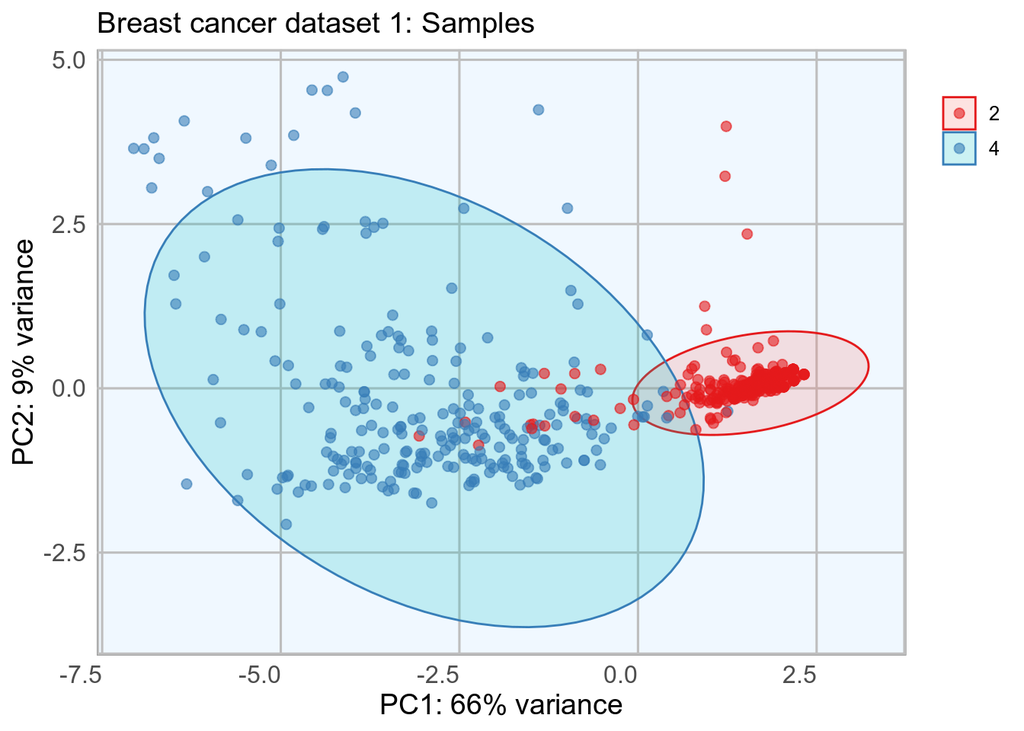

```r
library(grid)
p1 <- pca_func(data = t(diagnosis_data[, 2:10]), groups = as.character(diagnosis_data$classes), title = "Breast cancer dataset 1: Samples")
p2 <- pca_func(data = diagnosis_data[, 2:10], groups = as.character(colnames(diagnosis_data[, 2:10])), title = "Breast cancer dataset 1: Features", print_ellipse = FALSE)
plot(p1)
```

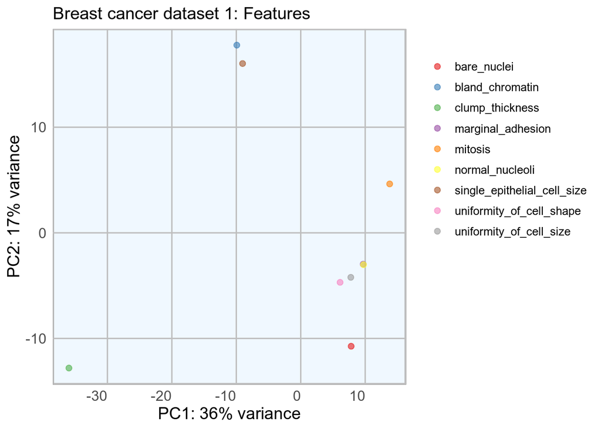

```r
plot(p2)
```

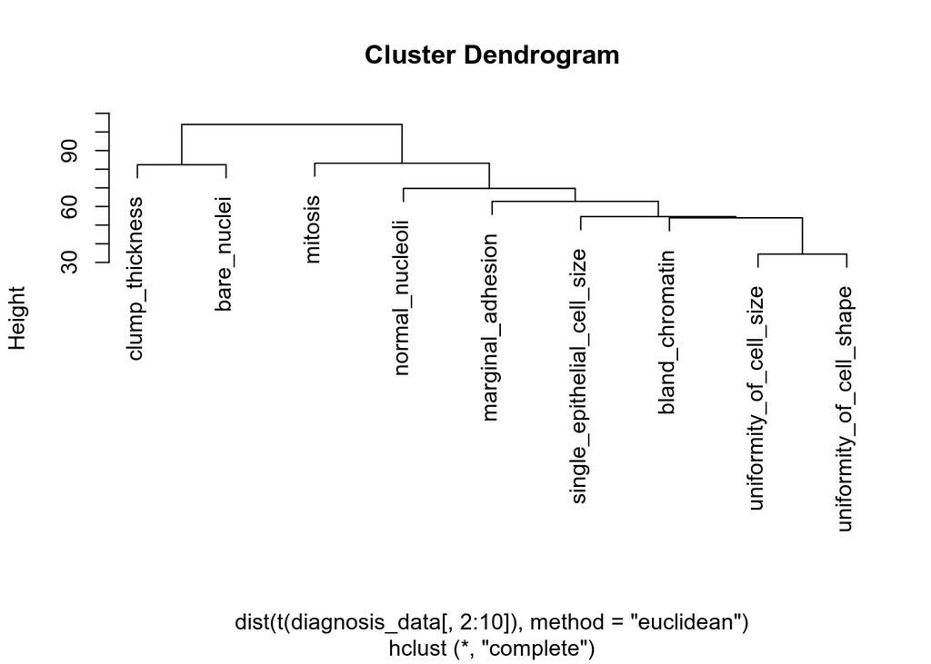

```r
h_1 <- hclust(dist(t(diagnosis_data[, 2:10]), method = "euclidean"), method = "complete")
plot(h_1)
```

```r
library(tidyr)
```

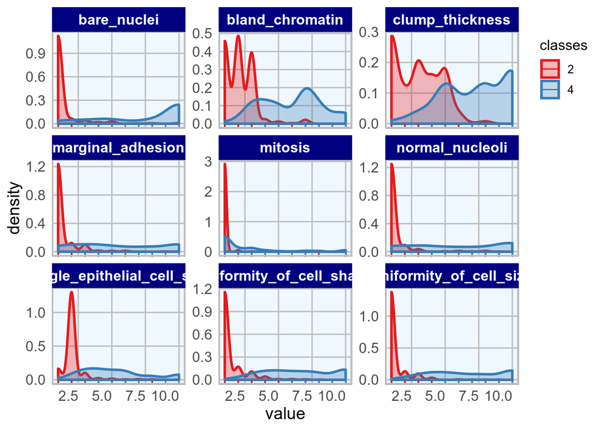

```r
diagnosis_data_gather <- diagnosis_data %>%
  gather(measure, value, clump_thickness:mitosis)

ggplot(data = diagnosis_data_gather, aes(x = value, fill = classes, color = classes)) +
  geom_density(alpha = 0.3, size = 1) +
  geom_rug() +
  scale_fill_brewer(palette = "Set1") +
  scale_color_brewer(palette = "Set1") +
  facet_wrap( ~ measure, scales = "free_y", ncol = 3)
```

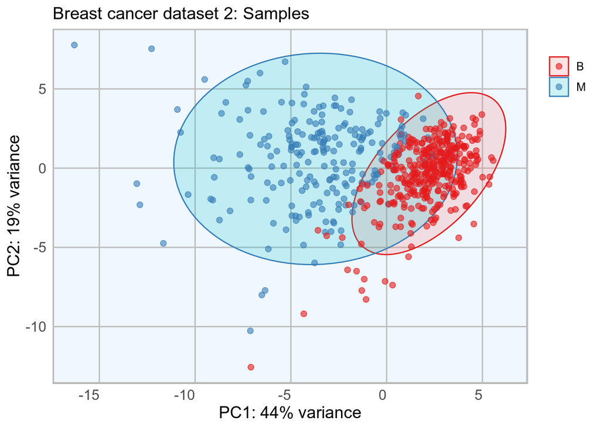

```r
p1 <- pca_func(data = t(diagnosis_data_2[, 3:32]), groups = as.character(diagnosis_data_2$diagnosis), title = "Breast cancer dataset 2: Samples")
p2 <- pca_func(data = diagnosis_data_2[, 3:32], groups = as.character(colnames(diagnosis_data_2[, 3:32])), title = "Breast cancer dataset 2: Features", print_ellipse = FALSE)
plot(p1)
```

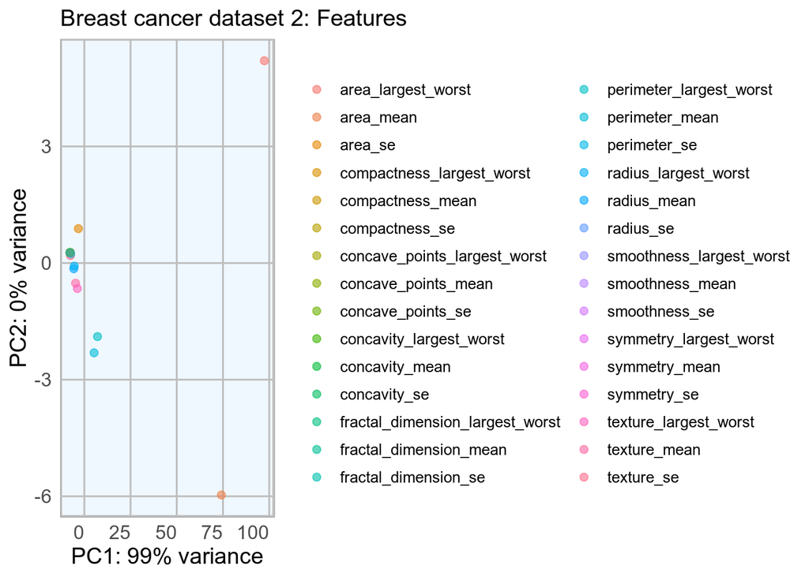

```r
plot(p2)
```

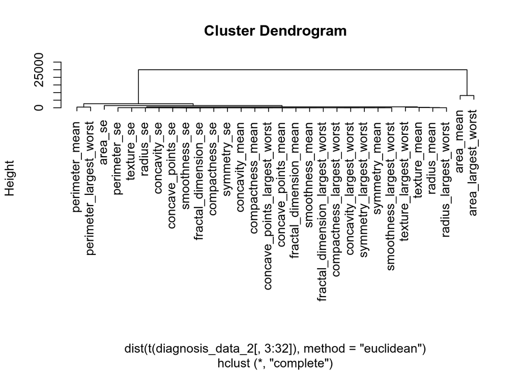

```r
h_2 <- hclust(dist(t(diagnosis_data_2[, 3:32]), method = "euclidean"), method = "complete")
plot(h_2)
```

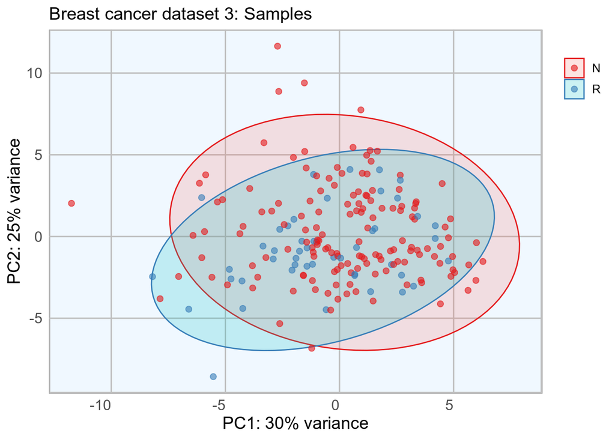

```r
p1 <- pca_func(data = t(diagnosis_data_3[, 2:34]), groups = as.character(diagnosis_data_3$outcome), title = "Breast cancer dataset 3: Samples")
p2 <- pca_func(data = diagnosis_data_3[, 2:34], groups = as.character(colnames(diagnosis_data_3[, 2:34])), title = "Breast cancer dataset 3: Features", print_ellipse = FALSE)
plot(p1)
```

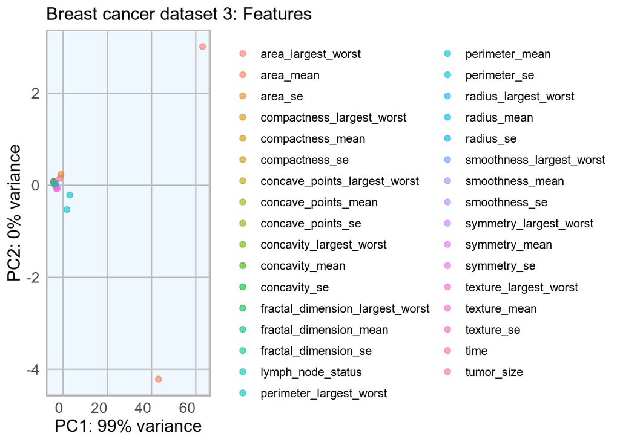

```r
plot(p2)
```

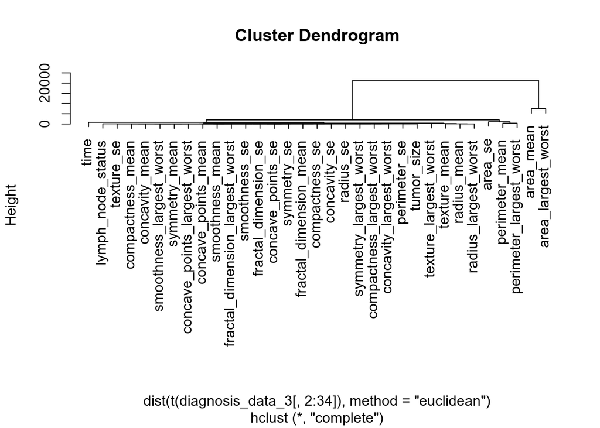

```r
h_3 <- hclust(dist(t(diagnosis_data_3[,2:34]), method = "euclidean"), method = "complete")
plot(h_3)
```

[figure not shown]

```r
diagnosis_data_3_gather <- diagnosis_data_3 %>%
  gather(measure, value, time:lymph_node_status)

ggplot(data = diagnosis_data_3_gather, aes(x = value, fill = outcome, color = outcome)) +
  geom_density(alpha = 0.3, size = 1) +
  geom_rug() +
  scale_fill_brewer(palette = "Set1") +
  scale_color_brewer(palette = "Set1") +
  facet_wrap( ~ measure, scales = "free_y", ncol = 3)
```

```r
# parallel processing
registerDoParallel()

# prepare training scheme
control <- trainControl(method = "repeatedcv", number = 10, repeats = 10)

feature_imp <- function(model, title) {

  # estimate variable importance
  importance <- varImp(model, scale = TRUE)

  # prepare dataframes for plotting
  importance_df_1 <- importance$importance
  importance_df_1$group <- rownames(importance_df_1)

  importance_df_2 <- importance_df_1
  importance_df_2$Overall <- 0

  importance_df <- rbind(importance_df_1, importance_df_2)

  plot <- ggplot() +
    geom_point(data = importance_df_1, aes(x = Overall, y = group, color = group), size = 2) +
    geom_path(data = importance_df, aes(x = Overall, y = group, color = group, group = group), size = 1) +
    theme(legend.position = "none") +
    labs(
      x = "Importance",
      y = "",
      title = title,
      subtitle = "Scaled feature importance",
      caption = "\nDetermined with Random Forest and
      repeated cross validation (10 repeats, 10 times)"
    )

  return(plot)

}
```

[figure not shown]

```r
# train the model
set.seed(27)
imp_1 <- train(classes ~ ., data = diagnosis_data, method = "rf", preProcess = c("scale", "center"), trControl = control)
p1 <- feature_imp(imp_1, title = "Breast cancer dataset 1")
set.seed(27)
imp_2 <- train(diagnosis ~ ., data = diagnosis_data_2[, -1], method = "rf", preProcess = c("scale", "center"), trControl = control)
p2 <- feature_imp(imp_2, title = "Breast cancer dataset 2")
set.seed(27)
imp_3 <- train(outcome ~ ., data = diagnosis_data_3, method = "rf", preProcess = c("scale", "center"), trControl = control)
p3 <- feature_imp(imp_3, title = "Breast cancer dataset 3")
grid.arrange(p1, p2, p3, ncol = 3, widths = c(0.3, 0.35, 0.35))
```

Correlation

```r
library(caret)
set.seed(27)
diagnosis_data_index <- createDataPartition(diagnosis_data$classes, p = 0.7, list = FALSE)
diagnosis_data_train <- diagnosis_data[diagnosis_data_index, ]
diagnosis_data_test  <- diagnosis_data[-diagnosis_data_index, ]
```

Dataset 2

```r
set.seed(27)
diagnosis_data_2_index <- createDataPartition(diagnosis_data_2$diagnosis, p = 0.7, list = FALSE)
diagnosis_data_2_train <- diagnosis_data_2[diagnosis_data_2_index, ]
diagnosis_data_2_test  <- diagnosis_data_2[-diagnosis_data_2_index, ]
```

Dataset 3

```r
set.seed(27)
diagnosis_data_3_index <- createDataPartition(diagnosis_data_3$outcome, p = 0.7, list = FALSE)
diagnosis_data_3_train <- diagnosis_data_3[diagnosis_data_3_index, ]
diagnosis_data_3_test  <- diagnosis_data_3[-diagnosis_data_3_index, ]
```

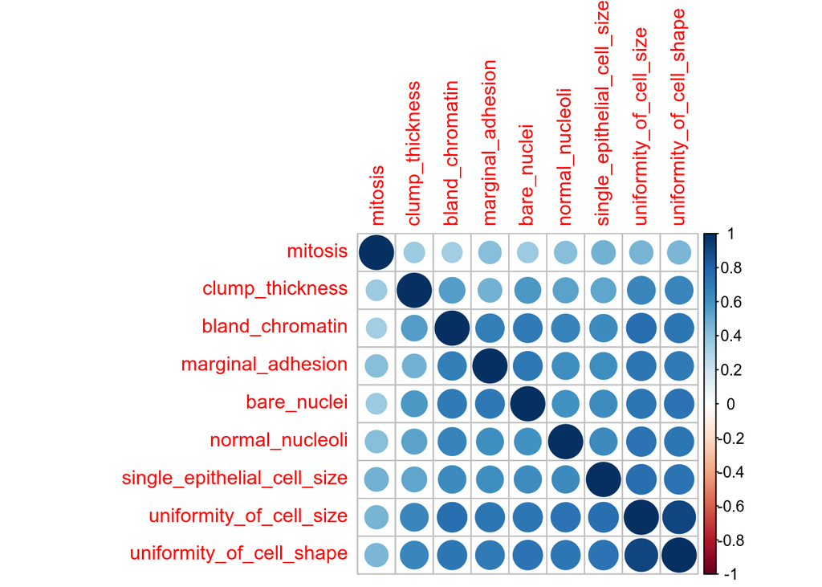

```r
library(corrplot)
# calculate correlation matrix
corMatMy <- cor(diagnosis_data_train[, -1])
corrplot(corMatMy, order = "hclust")
```

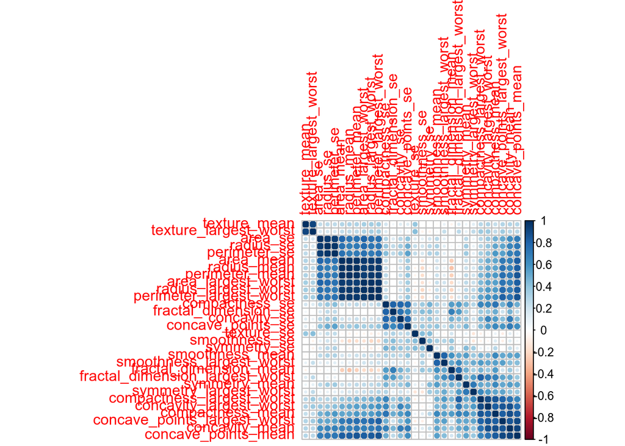

```r
corMatMy <- cor(diagnosis_data_2_train[, 3:32])
corrplot(corMatMy, order = "hclust")
```

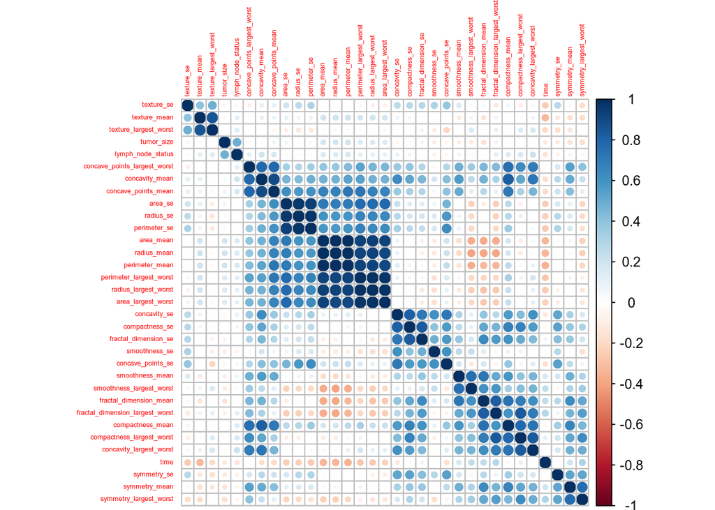

```r
corMatMy <- cor(diagnosis_data_3_train[, -1])
corrplot(corMatMy, order = "hclust", tl.cex = 0.4)
```